# RRN audit of five severe 2024 mortality misses

Mackay, Linnet, Lizard Island NW, Eyrie and Swinger

# Main finding

The five reefs do not share one RRN explanation.

- **Linnet and Eyrie have strong low-level COTS signals.** Their observed and spatially modelled COTS values are unusually high relative to reefs in the same one-degree latitude band. These values should be treated as evidence of elevated COTS pressure, not automatically labelled a formal outbreak.
- **Linnet, Eyrie and Swinger experienced unusual coloured-water exposure relative to their own histories.** Each 2023–24 value is at the 95th percentile of its previous decade. Water colour also aligns positively with underprediction across the full set of 2024 manta reefs.
- **Lizard Island NW has very low coral-sink connectivity.** This suggests low connectivity-mediated rescue or recovery potential, although it is not an acute mortality agent and cannot by itself explain rapid post-bleaching loss.
- **Mackay is unexplained by the gridded RRN predictors, but not by its field record.** It has no modelled cyclone-wave exposure, no observed COTS, modest water colour and exceptionally low DHW relative to nearby reefs. However, its retained survey tooltip explicitly records coral bleaching, Cyclone Jasper and flood waters. The remaining miss therefore points to inadequate spatial or temporal resolution in the gridded freshwater/cyclone proxies.

The misses are **not simply caused by a missing Acropora column**. The model has a preceding-year Acropora proportion for all five reefs. Linnet, Lizard NW and Mackay use observed reef/depth-year composition; only Eyrie and Swinger use past-only spatial-temporal interpolation. The earlier assignment of Mackay to an interpolated 42.2% Acropora value was a crosswalk error: its corrected observed value is 11.1%. Setting Acropora to 90% in each reef’s original held-out BRT still leaves 23–44 percentage points of underprediction.

# Is missing community composition the main cause?

Fold-specific Acropora counterfactuals

| Reef | Source | Assigned Acropora | Observed | Prediction at assigned | Prediction at 90% Acropora | Remaining miss at 90% |
| --- | --- | --- | --- | --- | --- | --- |
| Linnet | Observed depth/year | 63.4% | 71.5% | 24.2% | 27.3% | 44.1% |
| Mackay | Observed depth/year | 11.1% | 61.3% | 10.5% | 17.5% | 43.7% |
| Eyrie | Past-only spatial-temporal IDW | 51.5% | 52.6% | 19.2% | 22.4% | 30.2% |
| Lizard Island | Observed depth/year | 14.9% | 46.2% | 9.3% | 22.3% | 23.9% |
| Swinger | Past-only spatial-temporal IDW | 56.9% | 34.6% | 8.4% | 11.2% | 23.4% |

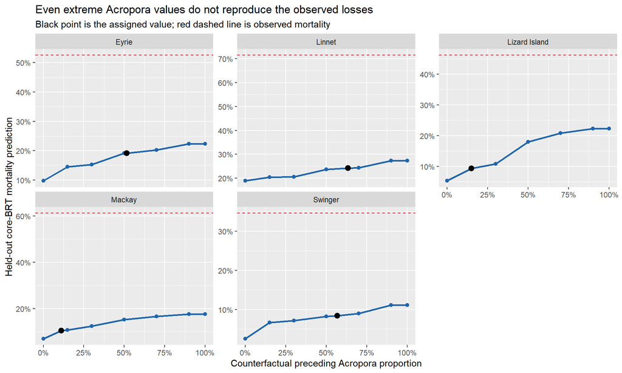

This result separates two issues:

1. **Acropora uncertainty:** Eyrie and Swinger do not have direct reef-year Acropora observations. Better composition data could increase or decrease their predicted susceptibility. Lizard NW and Mackay are the most sensitive to raising Acropora, but still remain substantially underestimated.
2. **Unrepresented weedy assemblages:** preceding `prop_acropora_pre` is only the fraction of hard coral assigned to *Acropora*. A reef dominated by other fast-growing, disturbance-sensitive or recently recruited taxa is not represented. If the post-recovery communities at these reefs were compositionally young or dominated by other weedy taxa, the current model would classify them as less susceptible than they actually were.

The next community improvement should therefore be a broader **community-susceptibility/recovery-state index**, not merely replacement of missing Acropora values. It should distinguish Acropora, other fast-growing susceptible taxa or growth forms, massive/stress-tolerant corals, and the age or time-since-recovery structure where attainable. Composition provenance and uncertainty should accompany each prediction.

# What was extracted

All six individual-pressure variables and all four derived metric families were extracted for all five reefs. This gives 860 individual pressure records and 120 metric records. The original workbook is not modified.

The valid pressure window for the 2024 bleaching event is summer `202324`. COTS uses fiscal July–June, cyclone and DHW use November–April, and coloured water uses December–April. Coral-sink connectivity is static.

The newest disturbance (`cmex`) and combined resilience (`cmfi`/`quad`) metrics include summer `202425`. They are retained in the extract but flagged as post-event leakage and are not used to explain 2024 mortality. Recovery-potential `cmfr` metrics ending in `202324` can be examined without that specific leakage.

Extraction and reference-table coverage

| item | value |
| --- | --- |
| RRN reefs in individual pressure data | 3862 |
| RRN reefs matched to AIMS reference | 505 |
| Target reefs requested | 5 |
| Target reefs present in pressure data | 5 |
| Target reefs present in metrics data | 5 |

The AIMS monitoring reference assigns sectors to only 505 of the 3,862 RRN reefs. Primary peer percentiles therefore use all RRN reefs in the same one-degree latitude band. Sector-region percentiles are secondary.

# Event-level pressure profile

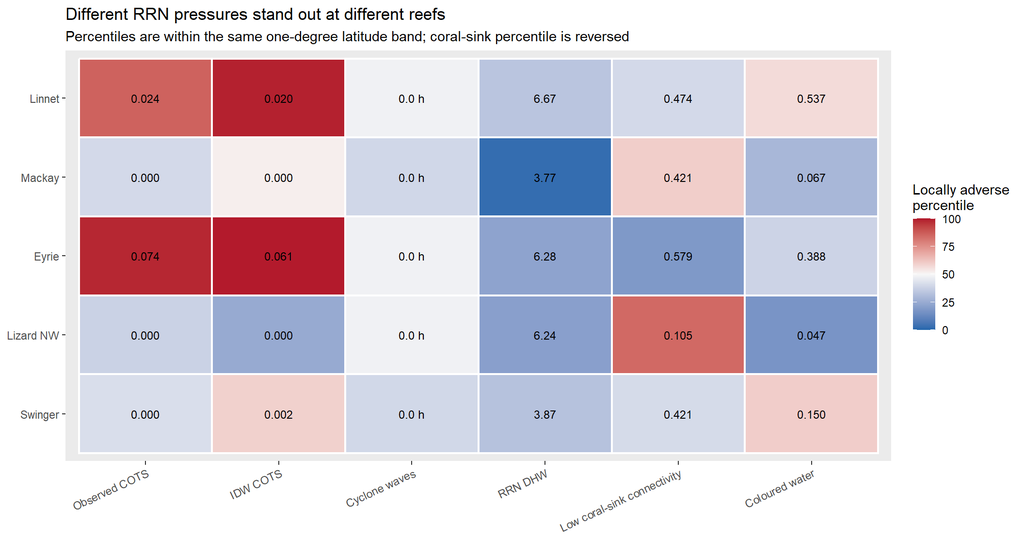

2024 mortality and valid RRN event pressures

| Reef | Region | Observed mortality | Core underprediction | DHW | Pre-event Acropora | Observed COTS/tow | IDW COTS/tow | Coloured-water frequency | Cyclone 4 m-wave hours | Coral-sink index | Field disturbance record |
| --- | --- | --- | --- | --- | --- | --- | --- | --- | --- | --- | --- |
| Linnet | Northern GBR | 71.5% | 47.3% | 6.73 | 63.4% | 0.0243 | 0.0201 | 0.537 | 0 | 0.474 | DHW 6.73 coral bleaching |
| Mackay | Central GBR | 61.3% | 50.8% | 3.52 | 11.1% | 0.0000 | 0.0004 | 0.067 | 0 | 0.421 | DHW 4.03 coral bleaching, Cyclone Jasper, flood waters |
| Eyrie | Northern GBR | 52.6% | 33.4% | 6.27 | 51.5% | 0.0738 | 0.0613 | 0.388 | 0 | 0.579 | DHW 6.27 to 6.32 coral bleaching |
| Lizard NW | Northern GBR | 46.2% | 36.8% | 6.27 | 14.9% | 0.0000 | 0.0000 | 0.047 | 0 | 0.105 | DHW 6.27 aerial bl 4 coral bleaching |
| Swinger | Northern GBR | 34.6% | 26.2% | 3.87 | 56.9% | 0.0000 | 0.0025 | 0.150 | 0 | 0.421 | DHW 3.87 coral bleaching |

# Reef-specific interpretation

## Linnet

This is the strongest RRN case for **compound thermal susceptibility, freshwater/plume exposure and low-level COTS pressure**. Its one-year recovery potential is also relatively low GBR-wide. The latest `quad = 4` and very low `cmfi` are consistent with poor resilience, but include 2024–25 disturbance information and must not be used as pre-event predictors.

## Eyrie

Eyrie’s COTS signal is the strongest of the five reefs: observed COTS per tow is at the 98th local percentile and the IDW estimate at the 99.7th. Its coloured-water frequency of 0.388 is the reef’s 95th within-decade percentile, although only the 38th percentile among all latitude-band reefs. Pre-event Acropora is high at 51.5%.

The RRN evidence therefore supports **elevated local COTS pressure plus an unusually plume-affected year for this reef**, rather than an exceptionally high regional plume exposure. Its recovery-potential metrics are high, so low generic recovery potential is not a convincing explanation.

## Lizard Island NW

Lizard NW has no RRN cyclone-wave or COTS signal and low coloured-water exposure. Its distinctive value is a coral-sink index of 0.105, only the 15.6th latitude-band percentile; expressed as vulnerability, this is the 84.4th percentile.

Low connectivity could reduce demographic rescue and longer-term recovery, but it is not direct evidence of the acute mortality mechanism. The reef remains a candidate for an unmeasured local freshwater pulse, finer-scale thermal exposure, taxonomic susceptibility, disease or another local disturbance.

## Swinger

Swinger experienced only 3.87 DHW and has no observed COTS or cyclone-wave exposure. Coloured-water frequency is 0.150: the 95th percentile of its own decade, 68th percentile GBR-wide and 60th percentile locally.

The main RRN hypothesis is therefore a **reef-specific coloured-water anomaly** acting additively with thermal stress. The signal is meaningful historically but not extreme compared with other nearby reefs, and the recovery-potential metrics are high. It remains a partial rather than complete explanation.

## Mackay

Mackay is the largest unexplained miss: 61.3% observed mortality and 50.8 percentage points of core-model underprediction. RRN DHW is 3.77, very close to the model input of 3.52 and only the 2.6th percentile of its latitude band. Cyclone exposure and observed COTS are zero; coloured-water frequency is only the 29th local percentile, although it is at the 80th percentile relative to the reef’s preceding ten event years. Recovery-potential metrics are high.

There is **no convincing gridded RRN explanation for Mackay**, but the field record explicitly lists `coral bleaching, Cyclone Jasper, flood waters`. The likely issue is therefore that seasonal water-colour, rainfall and grid-cell wave exposure do not resolve the acute local runoff/freshwater pulse. This reef should remain a high-resolution exposure-review case rather than being used to force a general DHW curve upward.

# Historical context

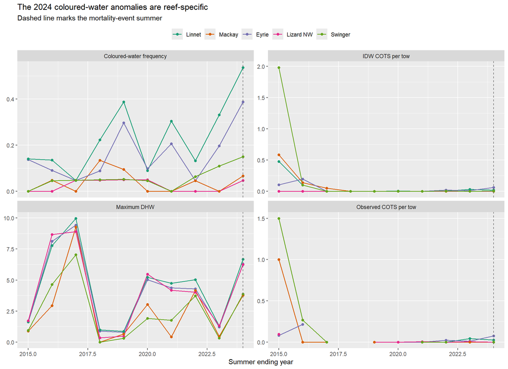

# Do these variables explain residuals across manta reefs?

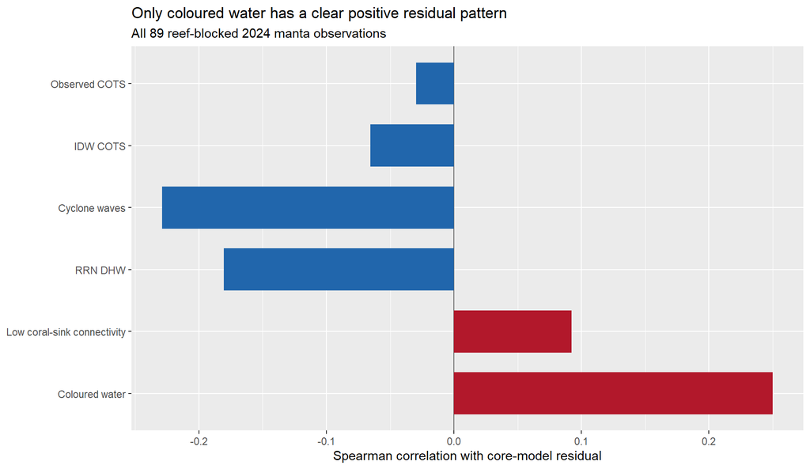

COTS is not positively associated with residuals across the whole manta dataset. Eyrie and Linnet are therefore **reef-specific COTS flags**, not evidence that COTS generally explains the 2024 model miss. Cyclone-wave exposure is negatively associated with residuals and does not explain these five reefs.

# Recovery metrics and leakage boundary

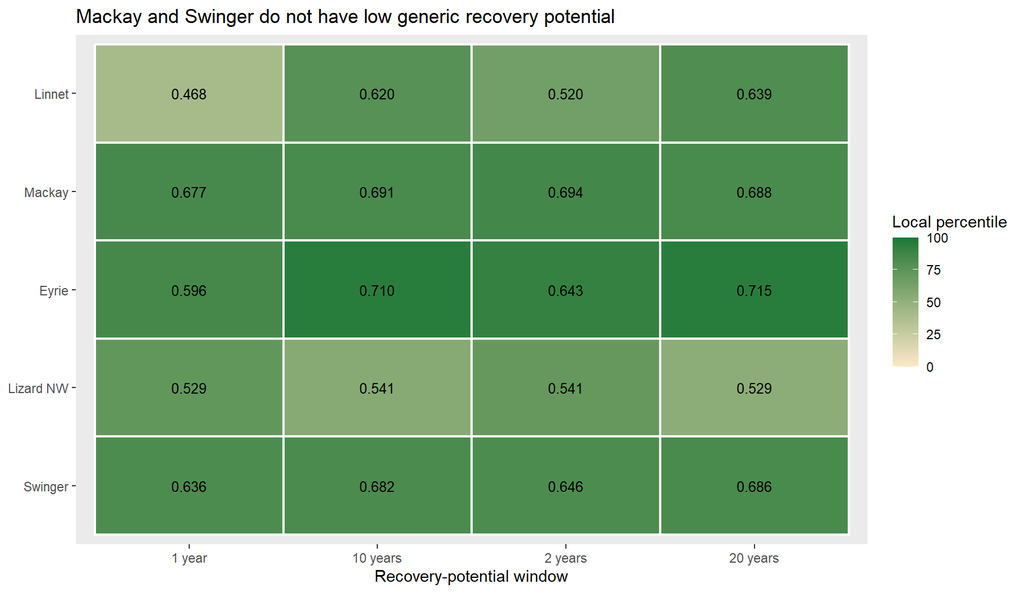

Linnet has the weakest recent recovery-potential value of the five (`cmfr_1y = 0.468`; 16.6th percentile GBR-wide), while Mackay and Swinger are consistently high. The `cmfr` metric combines coral-sink connectivity and water colour; it is contextual rather than an independent mechanism.

# Recommended next checks

1. Add the raw 2023–24 COTS variables to a **targeted sensitivity**, keeping them distinct from disturbance attribution. Concentrate on Linnet and Eyrie; do not infer a GBR-wide COTS mechanism from these two reefs.
2. Retain water colour as an additive freshwater/plume predictor and inspect higher temporal-resolution plume/rainfall/salinity data for Linnet, Eyrie and Swinger.
3. Treat Lizard NW’s low coral-sink index as a resilience/recovery flag, not an acute mortality exposure.
4. Mackay’s lineage and composition crosswalk are now corrected. Prioritise fine-scale rainfall, runoff, salinity and flood-plume products around its survey interval; the field record already identifies Jasper and flood waters even though the gridded predictors miss them.
5. Never use the latest `cmex`, `cmfi` or `quad` metrics to predict 2024 mortality because they include summer 2024–25.